# 73_strings

## full code and all files in GDrive available here:

#### link: https://drive.google.com/drive/folders/1yvkY-UJqsBnt021BbsGoMfGYbPOaK-_1?usp=sharing

Stanford Sentiment Treebank V1.0

This is the dataset of the paper:

Recursive Deep Models for Semantic Compositionality Over a Sentiment Treebank Richard Socher, Alex Perelygin, Jean Wu, Jason Chuang, Christopher Manning, Andrew Ng and Christopher Potts Conference on Empirical Methods in Natural Language Processing (EMNLP 2013)

If you use this dataset in your research, please cite the above paper.

@incollection{SocherEtAl2013:RNTN, title = {{Parsing With Compositional Vector Grammars}}, author = {Richard Socher and Alex Perelygin and Jean Wu and Jason Chuang and Christopher Manning and Andrew Ng and Christopher Potts}, booktitle = {{EMNLP}}, year = {2013} }

This file includes:

1. original_rt_snippets.txt contains 10,605 processed snippets from the original pool of Rotten Tomatoes HTML files. Please note that some snippet may contain multiple sentences.
2. dictionary.txt contains all phrases and their IDs, separated by a vertical line |
3. sentiment_labels.txt contains all phrase ids and the corresponding sentiment labels, separated by a vertical line. Note that you can recover the 5 classes by mapping the positivity probability using the following cut-offs: [0, 0.2], (0.2, 0.4], (0.4, 0.6], (0.6, 0.8], (0.8, 1.0] for very negative, negative, neutral, positive, very positive, respectively. Please note that phrase ids and sentence ids are not the same.
4. SOStr.txt and STree.txt encode the structure of the parse trees. STree encodes the trees in a parent pointer format. Each line corresponds to each sentence in the datasetSentences.txt file. The Matlab code of this paper will show you how to read this format if you are not familiar with it.
5. datasetSentences.txt contains the sentence index, followed by the sentence string separated by a tab. These are the sentences of the train/dev/test sets.
6. datasetSplit.txt contains the sentence index (corresponding to the index in datasetSentences.txt file) followed by the set label separated by a comma: 1 = train 2 = test 3 = dev

Please note that the datasetSentences.txt file has more sentences/lines than the original_rt_snippet.txt. Each row in the latter represents a snippet as shown on RT, whereas the former is each sub sentence as determined by the Stanford parser.

For comparing research and training models, please use the provided train/dev/test splits.

#### download glove for pre-trained embedding

```python
import os
# os.chdir("drive/")
# os.chdir("My Drive/")
# os.chdir("73-strings")
!ls
# !gzip -dk glove.6B.100d.txt.gz
```

```
drive  sample_data
```

```python
# !wget https://github.com/allenai/spv2/blob/master/model/glove.6B.100d.txt.gz
```

[output not shown]

#### dictionary.txt containes phrases and their IDs, separated by a vertical line |

#### and sentiment_labels.txt containes all phrase IDs and corresponding sentiment labels, separated by a vertical line.

#### datasetSentences.txt contains the sentence index, followed by the sentence string separated by a tab. These are the sentences of the train/dev/test sets.

#### datasetSplit.txt contains the sentence index (corresponding to the index in datasetSentences.txt file) followed by the set label separated by a comma: 1 = train 2 = test 3 = dev

### all required imports

```python
import pandas as pd
import numpy as np
import matplotlib.pyplot as plt
import os
import re
import nltk
from nltk import word_tokenize, sent_tokenize, FreqDist
from nltk.util import ngrams
from nltk.corpus import stopwords
from nltk.stem import WordNetLemmatizer
from nltk.tokenize import RegexpTokenizer
import seaborn as sns
nltk.download('wordnet')
nltk.download('stopwords')

from sklearn.preprocessing import LabelEncoder

import keras
from keras.models import Sequential, model_from_json, load_model
from keras.layers import Dense, Dropout, Flatten, LSTM, Bidirectional
from keras.layers.embeddings import Embedding
from keras.preprocessing import sequence
import h5py
from nltk.tokenize import RegexpTokenizer
```

### process_sentences is function that pre-process all data and stores train, test and val data to separate files for further uses.

### replace_path_73_strings with given data directory path that contains all files by standford-tree-bank dataset

```python
# root_directory path
path_73_strings = "/content/drive/My Drive/73-strings"

def process_sentences(BASE_PATH):

  # define each individual files path by appending their names
  datasetSenteces_path = BASE_PATH + '/datasetSentences.txt'
  datasetSplit_path = BASE_PATH + '/datasetSplit.txt'
  dictionary_path = BASE_PATH + '/dictionary.txt'
  sentiment_labels_path = BASE_PATH + '/sentiment_labels.txt'

  # read each file by either read_csv or read_table and add header=None if there is no header and add separator
  df_sentences = pd.read_table(datasetSenteces_path)
  df_split_label = pd.read_csv(datasetSplit_path)
  df_dictionary =  pd.read_table(dictionary_path, sep='|', header=None)
  df_sentiment_label = pd.read_table(sentiment_labels_path, sep='|')

  # printing shape of each one
  print(df_sentences.shape)
  print(df_split_label.shape)
  print(df_dictionary.shape)
  print(df_sentiment_label.shape)

  # sort by sentence_index because sentences and split_label have same shape with one to one mapping
  df_sentences.sort_values('sentence_index')
  df_split_label.sort_values('sentence_index')

  # combine them to get processed sentences dataframe
  # df_sentences_processed = pd.concat([df_sentences, df_split_label], axis=1)
  # using inner join
  df_sentences_processed = pd.merge(left=df_sentences, right=df_split_label, left_on='sentence_index', right_on='sentence_index')

  # sentence_index is no more required -> drop it from dataframe
  df_sentences_processed.drop('sentence_index', axis='columns', inplace=True)
  print(df_sentences_processed.head(3))

  # for dictionary and sentiment_label define short name for their columns
  df_dictionary.columns = ['phrase','phrase_id']
  df_sentiment_label.columns = ['phrase_id','sentiment_value']

  # sort by phrase_id because dictonary and sentiment_value for that have one to one mapping with having same shape
  df_dictionary.sort_values('phrase_id')
  df_sentiment_label.sort_values('phrase_id')

  # combine them so we can get dictionary_processed
  # df_dictionary_processed = pd.concat([df_dictionary, df_sentiment_label], axis=1)
  # using inner join
  df_dictionary_processed = pd.merge(left=df_dictionary, right=df_sentiment_label, left_on='phrase_id', right_on='phrase_id')

  # phrase_id is no more required -> drop it.
  df_dictionary_processed.drop('phrase_id', axis='columns', inplace=True)
  print(df_dictionary_processed.head(3))

  # apply inner join on sentence and phrase column from sentences-processed and dictionary_processed respectively.
  df_final = pd.merge(left=df_sentences_processed, right=df_dictionary_processed, left_on='sentence', right_on='phrase')

  df_final.drop('phrase',axis='columns',inplace=True)
  print(df_final.shape)
  print(df_final.head(5))
  print(df_final.columns)

  return df_final
```

```python
processed = process_sentences(path_73_strings)
```

```
(11855, 2)
(11855, 2)
(239232, 2)
(239232, 2)
                                            sentence  splitset_label
0  The Rock is destined to be the 21st Century 's...               1
1  The gorgeously elaborate continuation of `` Th...               1
2                     Effective but too-tepid biopic               2
  phrase  sentiment_value
0      !          0.50000
1    ! '          0.52778
2   ! ''          0.50000
(11286, 3)
                                            sentence  ...  sentiment_value
0  The Rock is destined to be the 21st Century 's...  ...          0.69444
1  The gorgeously elaborate continuation of `` Th...  ...          0.83333
2                     Effective but too-tepid biopic  ...          0.51389
3  If you sometimes like to go to the movies to h...  ...          0.73611
4  Emerges as something rare , an issue movie tha...  ...          0.86111

[5 rows x 3 columns]
Index(['sentence', 'splitset_label', 'sentiment_value'], dtype='object')
```

#### After getting all the data processed with having only 3 fields ['sentence', 'splitset_label', 'sentiment_value']

#### This block is creating new column = 'sentiment_tag' based on 'sentiment_value' in 5 tags [very negative, negative, neutral, positive, very positive] respectively

```python
processed.loc[(processed['sentiment_value'] >= 0) & (processed['sentiment_value'] <= 0.2), 'sentiment_tag'] = 'very_negative'
processed.loc[(processed['sentiment_value'] > 0.2) & (processed['sentiment_value'] <= 0.4), 'sentiment_tag'] = 'negative'
processed.loc[(processed['sentiment_value'] > 0.4) & (processed['sentiment_value'] <= 0.6), 'sentiment_tag'] = 'neutral'
processed.loc[(processed['sentiment_value'] > 0.6) & (processed['sentiment_value'] <= 0.8), 'sentiment_tag'] = 'positive'
processed.loc[(processed['sentiment_value'] > 0.8) & (processed['sentiment_value'] <= 1), 'sentiment_tag'] = 'very_positive'
# print(processed['sentiment_tag'])

Le = LabelEncoder()

processed['sentiment_tag'] = Le.fit_transform(processed['sentiment_tag'])
```

[output not shown]

### all text by combining whole dataset into one string called full_text

#### counting number of UNIQUE words

#### most common words by frequency counter from nltk.probability.FreqDist

#### finding length of shortest and longest words and their frequency

```python
full_text = " ".join(processed['sentence'].values)
print(full_text[:100])
```

```
The Rock is destined to be the 21st Century 's new `` Conan '' and that he 's going to make a splash
```

```python
full_text_word = full_text.split()
print(full_text_word[:200])
```

```
['The', 'Rock', 'is', 'destined', 'to', 'be', 'the', '21st', 'Century', "'s", 'new', '``', 'Conan', "''", 'and', 'that', 'he', "'s", 'going', 'to', 'make', 'a', 'splash', 'even', 'greater', 'than', 'Arnold', 'Schwarzenegger', ',', 'Jean-Claud', 'Van', 'Damme', 'or', 'Steven', 'Segal', '.', 'The', 'g…
```

```python
print("total number of words {}".format(len(full_text_word)))
print("total unique number of words {}".format(len(set(full_text_word))))
```

```
total number of words 213091
total unique number of words 20868
```

```python
from nltk.tokenize import word_tokenize
from nltk.probability import FreqDist

fdist = FreqDist(full_text_word)

print("most common 50 words {}".format(fdist.most_common(50)))
```

```
most common 50 words [('.', 10610), (',', 9376), ('the', 7890), ('a', 5740), ('and', 5727), ('of', 5698), ('to', 3959), ('is', 3339), ("'s", 3291), ('that', 2467), ('it', 2376), ('in', 2355), ('The', 1646), ('as', 1586), ('film', 1502), ('but', 1428), ('with', 1397), ('for', 1272), ('movie', 1247), …
```

```python
short = set(s for s in full_text_word if len(s)<4)
short = [(s, fdist[s]) for s in short]
short.sort(key=lambda x:x[1], reverse=True)
short[:20]
```

```
[('.', 10610),
 (',', 9376),
 ('the', 7890),
 ('a', 5740),
 ('and', 5727),
 ('of', 5698),
 ('to', 3959),
 ('is', 3339),
 ("'s", 3291),
 ('it', 2376),
 ('in', 2355),
 ('The', 1646),
 ('as', 1586),
 ('but', 1428),
 ('for', 1272),
 ('its', 1231),
 ('A', 1157),
 ('you', 1009),
 ('an', 975),
 ('It', 903)]
```

```python
long_ = set(s for s in full_text_word if len(s)>15)
long_ = [(s, fdist[s]) for s in long_]
long_.sort(key=lambda x:x[1], reverse=True)
long_[:20]
```

```
[('thought-provoking', 18),
 ('characterizations', 10),
 ('well-intentioned', 8),
 ('characterization', 7),
 ('writer\\/director', 6),
 ('Writer\\/director', 6),
 ('self-deprecating', 6),
 ('computer-generated', 5),
 ('incomprehensible', 5),
 ('English-language', 4),
 ('fish-out-of-water', 4),
 ('self-consciously', 3),
 ('connect-the-dots', 3),
 ('character-driven', 3),
 ('autobiographical', 3),
 ('bargain-basement', 3),
 ('mother\\/daughter', 3),
 ('characteristically', 3),
 ('counter-cultural', 2),
 ('African-American', 2)]
```

### using nltk for stop_words, lemmatizer, tokenizing

```python
import nltk
from nltk import word_tokenize, sent_tokenize, FreqDist
from nltk.util import ngrams
from nltk.corpus import stopwords
from nltk.stem import WordNetLemmatizer
from nltk.tokenize import RegexpTokenizer
import seaborn as sns
# nltk.download('wordnet')
# nltk.download('stopwords')
```

### tokenize full_text using regular expression tokenizer RegexpTokenizer

```python
tokeniser = RegexpTokenizer("[A-Za-z]+")
tokens = tokeniser.tokenize(full_text)
print(tokens[:20], "\n")
```

```
['The', 'Rock', 'is', 'destined', 'to', 'be', 'the', 'st', 'Century', 's', 'new', 'Conan', 'and', 'that', 'he', 's', 'going', 'to', 'make', 'a']
```

### total and unique tokens

```python
print(f"Number of tokens: {len(tokens)}")
print(f"Number of unique tokens: {len(set(tokens))}")
```

```
Number of tokens: 193425
Number of unique tokens: 19112
```

### lemmatiser for lemmatize words so that one word can not be there in multiple form like THe, thE, the, The etc.

```python
lemmatiser = WordNetLemmatizer()
tokens_norm = [lemmatiser.lemmatize(t.lower(), "v") for t in tokens]
print(f"Number of unique tokens: {len(set(tokens_norm))}")
```

```
Number of unique tokens: 13907
```

### counting tokens and plotting chart fornumber of characters per token

```
Average number of characters per token: 4.6589
```

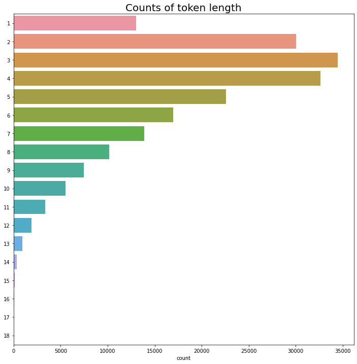

```python
# Create list of token lengths for each token
token_length = [len(t) for t in tokens]
# Average number of characters per token
print(f"Average number of characters per token: {round(np.mean(token_length),4)}")
# Plot distribution
plt.figure(figsize=(12, 12))
sns.countplot(y=token_length)
plt.title("Counts of token length", size=20)
```

### stop_words

```python
# nltk.download('stopwords')
stop_words = stopwords.words("english")
print(f"There are {len(stop_words)} stopwords.\n")
print(stop_words)
```

```
There are 179 stopwords.

['i', 'me', 'my', 'myself', 'we', 'our', 'ours', 'ourselves', 'you', "you're", "you've", "you'll", "you'd", 'your', 'yours', 'yourself', 'yourselves', 'he', 'him', 'his', 'himself', 'she', "she's", 'her', 'hers', 'herself', 'it', "it's", 'its', 'itself', 'they', 'them', 'their', 'theirs', 'themselve…
```

### most frequent stop words

```python
freq_stopwords = [(sw, tokens_norm.count(sw)) for sw in stop_words]
freq_stopwords.sort(key=lambda x: x[1], reverse=True)
freq_stopwords[:10]
```

```
[('the', 9615),
 ('a', 6934),
 ('and', 5841),
 ('of', 5787),
 ('be', 5746),
 ('to', 4033),
 ('s', 3360),
 ('it', 3285),
 ('in', 2516),
 ('that', 2513)]
```

### how many percent stop words are there out of total tokens

```python
n_stopwords = len([t for t in tokens_norm if t in stop_words])
print(f"{n_stopwords} tokens are stop words.")
print(f"That is {round(100*n_stopwords/len(tokens_norm),2)}%.")
```

```
86454 tokens are stop words.
That is 44.7%.
```

### after removing stop words remaining tokens

```python
tokens_clean = [t for t in tokens_norm if t not in stop_words]
print(f"Number of tokens: {len(tokens_clean)}")
```

```
Number of tokens: 106971
```

### plots for n-grams uni-gram, bi-gram, tri-gram, four-gram

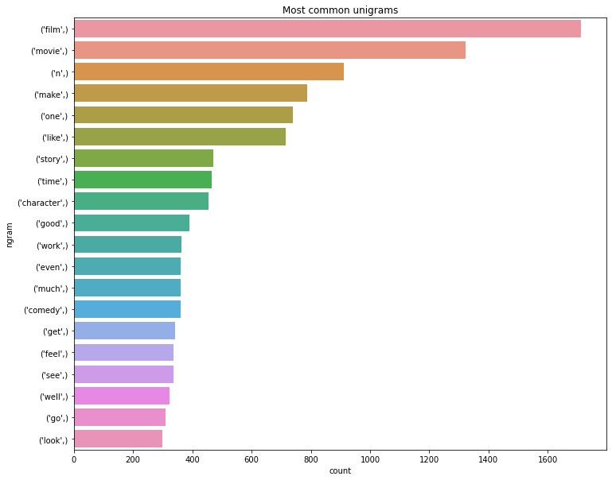

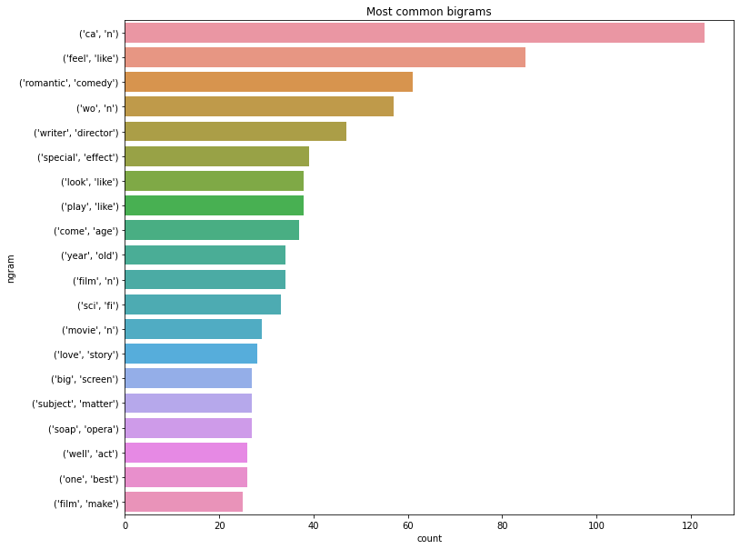

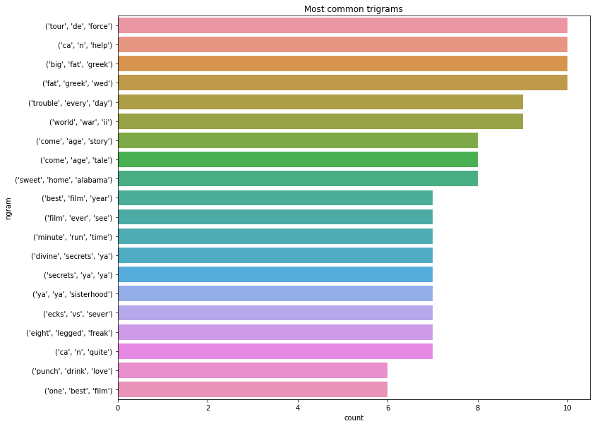

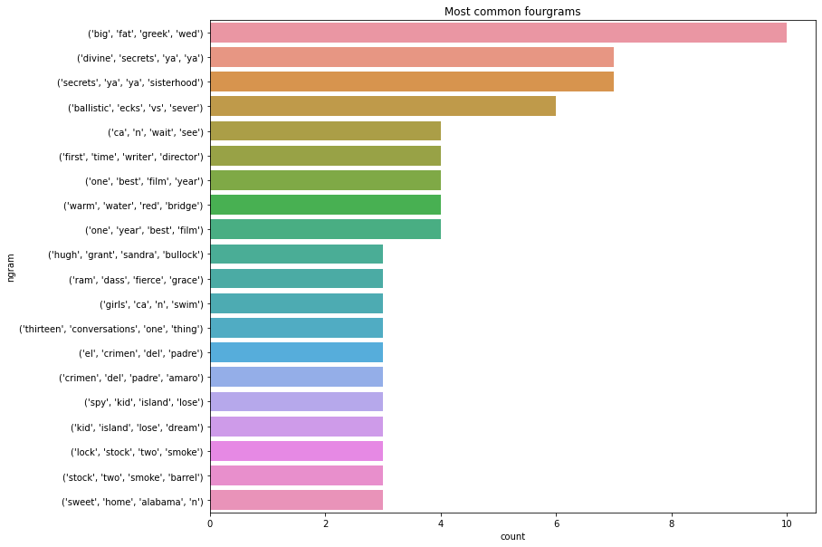

```python
def get_frequent_ngram(tokens, ngram, n=20):
    """Find most common n n-grams in tokens."""
    n_grams = ngrams(tokens, ngram)
    freq_dist = FreqDist(n_grams)
    top_freq = freq_dist.most_common(n)
    return pd.DataFrame(top_freq, columns=["ngram", "count"])
# Get frequent ngrams for all 4
for i in range(1,5):
    mapping = {1:"uni", 2:"bi", 3:"tri", 4:"four"}
    plt.figure(figsize=(12,10))
    sns.barplot(x="count", y="ngram", data=get_frequent_ngram(tokens_clean, i))
    plt.title(f"Most common {mapping[i]}grams");
```

### plotting barh from whole processed data on sentiment_tag

### this will tell us how data is distributed on sentiment_tag

[figure not shown]

```python
ax = processed['sentiment_tag'].value_counts(sort=False).plot.barh()
ax.set_xlabel("Number of Samples in total Set")
ax.set_ylabel("Label")
```

### dividing processed data into train, test, val based on 'splitset_label' value 1 = train 2 = test 3 = dev

```python
# define train, test, dev splits from processed data based on column 'splitset_label'
# 1 = train 2 = test 3 = dev

BASE_DIR = "/content/drive/My Drive/73-strings"

def train_test_dev(processed_data, BASE_DIR):
  train_data = processed_data.loc[processed_data['splitset_label'] == 1]
  test_data = processed_data.loc[processed_data['splitset_label'] == 2]
  dev_data  = processed_data.loc[processed_data['splitset_label'] == 3]

  train_data.drop('splitset_label', axis='columns', inplace=True)
  test_data.drop('splitset_label', axis='columns', inplace=True)
  dev_data.drop('splitset_label', axis='columns', inplace=True)

  print(processed_data.shape)
  print(train_data.shape, (train_data.shape[0]/processed_data.shape[0]))
  print(test_data.shape,  (test_data.shape[0]/processed_data.shape[0]))
  print(dev_data.shape,  (dev_data.shape[0]/processed_data.shape[0]))


  train_data_file_path = os.path.join(BASE_DIR, "new_data/train.csv")
  test_data_file_path = os.path.join(BASE_DIR, "new_data/test.csv")
  dev_data_file_path = os.path.join(BASE_DIR, "new_data/dev.csv")

  train_data.to_csv(train_data_file_path)
  test_data.to_csv(test_data_file_path)
  dev_data.to_csv(dev_data_file_path)

  return train_data, test_data, dev_data
```

```python
train_only, test_only, dev_only = train_test_dev(processed, BASE_DIR)
```

```
(11286, 4)
(8117, 3) 0.7192096402622719
(2125, 3) 0.1882863724968988
(1044, 3) 0.09250398724082935
```

### barh plot on train-data 'sentiment_tag'

### this will tell us how training - data is distributed on sentiment_tag

[figure not shown]

```python
ax = train_only['sentiment_tag'].value_counts(sort=False).plot.barh()
ax.set_xlabel("Number of Samples in training Set")
ax.set_ylabel("Label")
```

### barh plot on test-data 'sentiment_tag'

### this will tell us how testing - data is distributed on sentiment_tag

[figure not shown]

```python
ax = test_only['sentiment_tag'].value_counts(sort=False).plot.barh()
ax.set_xlabel("Number of Samples in training Set")
ax.set_ylabel("Label")
```

### barh plot on val-data 'sentiment_tag'

### this will tell us how validation - data is distributed on sentiment_tag

[figure not shown]

```python
ax = dev_only['sentiment_tag'].value_counts(sort=False).plot.barh()
ax.set_xlabel("Number of Samples in training Set")
ax.set_ylabel("Label")
```

```python
import os
import numpy as np
import keras
from keras.models import Sequential
from keras.layers import Dense
from keras.layers import Flatten
from keras.layers import LSTM
from keras.layers.embeddings import Embedding
from keras.layers import Bidirectional
from keras.preprocessing import sequence
from keras.layers import Dropout
import h5py
import train_code.utility_functions
from keras.models import model_from_json
from keras.models import load_model
from nltk.tokenize import RegexpTokenizer
from sklearn.preprocessing import LabelEncoder
```

### Now we will build whole pipeline for training and saving best model

### max_sequence_length - this function will find out maximum sequence lenth available in our data so we can add padded vector for smaller sequences

```python
def max_sequence_length(all_data):
  total_words = 0
  sequence_length = []
  max_seq_len = -1
  i = 0
  for index, row in all_data.iterrows():
    sentence = row['sentence']
    sentence_words = sentence.split(' ')
    sentence_words_length = len(sentence_words)
    total_words = total_words + sentence_words_length

    sequence_length.append(sentence_words_length)

    if max_seq_len < sentence_words_length:
      max_seq_len = sentence_words_length
    i += 1

  avg_words = total_words/index

  sentence_words_length_np = np.asarray(sentence_words_length)

  return max_seq_len, avg_words, sentence_words_length_np
```

### data_pipeline - this function will create actual data for training_features by replacing each word in sentence with its embedding vector given by embedding dictionary word_idx

```python
def data_pipeline(data, word_idx, weight_matrix, max_seq_len):
  number_of_rows = len(data)
  ids = np.zeros((number_of_rows, max_seq_len), dtype='int32')
  word_idx_lower = {k.lower(): v for k, v in word_idx.items()}

  i = 0
  for index, row in data.iterrows():
    sentence = row['sentence']
    sentence_words = sentence.split(' ')

    j = 0
    for word in sentence_words:
      word_lower = word.lower()

      try:
        ids[i][j] = word_idx_lower[word_lower]
      except Exception as e:
        if str(e) == word:
          ids[i][j] = 0
        continue
      j += 1
    i += 1

  return ids
```

### labels_matrix - this function will create matrix for labels this will actually map float sentiment values to categorical lables 0,1,2,3,4

```python
def labels_matrix(data):
  labels = data['sentiment_value']
  labels_float = labels.astype(float)

  categories = ['0','1','2','3','4']
  labels_mult = (labels_float * 5).astype(int)
  dummies = pd.get_dummies(labels_mult, prefix='', prefix_sep='')
  dummies = dummies.T.reindex(categories).T.fillna(0)
  labels_matrix = dummies.as_matrix()

  return labels_matrix
```

### load_embedding - this function is used for loading embedding saved in glove file for creating word_idx and weight_vectors

```python
def load_embeddings(glove_path):
  weight_vectors = []
  word_idx = {}

  with open(glove_path, encoding='utf-8') as f:
    for line in f:
      word, vec = line.split(u' ', 1)
      word_idx[word] = len(weight_vectors)
      weight_vectors.append(np.array(vec.split(), dtype=np.float32))


  weight_vectors.append(np.random.uniform(-0.05,0.05, weight_vectors[0].shape).astype(np.float32))

  return word_idx, np.stack(weight_vectors)
```

### create_model - this function will create model

### this model is birectional rnn with having loss = 'categorical_crossentropy' and optimizer = 'adam'

### the input_length will be max_words (maximum words can be possible in a sentence in data set)

```python
def create_model(weight_matrix, max_words, embedding_dimension):
  model = Sequential()
  model.add(Embedding(len(weight_matrix), embedding_dimension, weights=[weight_matrix], input_length=max_words, trainable=False))
  model.add(Bidirectional(LSTM(128, dropout=0.2, recurrent_dropout=0.2)))
  model.add(Dense(512, activation='relu'))
  model.add(Dropout(0.5))
  model.add(Dense(5, activation='softmax'))
  model.compile(loss='categorical_crossentropy', optimizer='adam', metrics=['accuracy'])
  print(model.summary())

  return model
```

### train_model - this function will return trained model on training data set with validating on validation dataset

### here two call_backs are used for early stopping and model checkpoint for saving best model by monitoring val_accuracy

### num_epochs = 25 but will trained before because of early stopping

### this will give test score and test accuracy

```python
def train_model(model, train_x, train_y, test_x, test_y, dev_x, dev_y, batch_size, BASE_DIR):
  best_model_path = os.path.join(BASE_DIR, '/model/best_model.hd5')
  save_best_model = keras.callbacks.ModelCheckpoint(best_model_path, monitor='val_acc', verbose=0, save_best_only=True, save_weights_only=False, mode='auto', period=1)
  early_stopping = keras.callbacks.EarlyStopping(monitor='val_loss', min_delta=0, patience=3, verbose=0, mode='auto')

  num_epochs = 25
  model.fit(train_x, train_y, batch_size=batch_size, epochs=num_epochs, validation_data=(dev_x, dev_y), callbacks=[save_best_model, early_stopping])
  score, accuracy = model.evaluate(test_x, test_y, batch_size=batch_size)

  print("Test score: {0}".format(score))
  print("Test accuracy: {0}".format(accuracy))

  return model
```

## Combine all functions defined above into single cell for processing all data from given txt file to trained model and saved as best_model.h5 in model sub-directory

```python
import os
import numpy as np
import pandas as pd
import matplotlib.pyplot as plt

import keras

from keras.models import Sequential, model_from_json, load_model
from keras.layers import Dense, Dropout, Flatten, LSTM, Bidirectional
from keras.layers.embeddings import Embedding
from keras.preprocessing import sequence
import h5py
from nltk.tokenize import RegexpTokenizer



def process_sentences(BASE_PATH):
  print("process sentencess call start")

  # define each individual files path by appending their names
  datasetSenteces_path = BASE_PATH + '/datasetSentences.txt'
  datasetSplit_path = BASE_PATH + '/datasetSplit.txt'
  dictionary_path = BASE_PATH + '/dictionary.txt'
  sentiment_labels_path = BASE_PATH + '/sentiment_labels.txt'

  # read each file by either read_csv or read_table and add header=None if there is no header and add separator
  df_sentences = pd.read_table(datasetSenteces_path)
  df_split_label = pd.read_csv(datasetSplit_path)
  df_dictionary =  pd.read_table(dictionary_path, sep='|', header=None)
  df_sentiment_label = pd.read_table(sentiment_labels_path, sep='|')

  # printing shape of each one
  # print(df_sentences.shape)
  # print(df_split_label.shape)
  # print(df_dictionary.shape)
  # print(df_sentiment_label.shape)

  # sort by sentence_index because sentences and split_label have same shape with one to one mapping
  df_sentences.sort_values('sentence_index')
  df_split_label.sort_values('sentence_index')

  # combine them to get processed sentences dataframe
  # df_sentences_processed = pd.concat([df_sentences, df_split_label], axis=1)
  # using inner join
  df_sentences_processed = pd.merge(left=df_sentences, right=df_split_label, left_on='sentence_index', right_on='sentence_index')

  # sentence_index is no more required -> drop it from dataframe
  df_sentences_processed.drop('sentence_index', axis='columns', inplace=True)
  # print(df_sentences_processed.head(3))

  # for dictionary and sentiment_label define short name for their columns
  df_dictionary.columns = ['phrase','phrase_id']
  df_sentiment_label.columns = ['phrase_id','sentiment_value']

  # sort by phrase_id because dictonary and sentiment_value for that have one to one mapping with having same shape
  df_dictionary.sort_values('phrase_id')
  df_sentiment_label.sort_values('phrase_id')

  # combine them so we can get dictionary_processed
  # df_dictionary_processed = pd.concat([df_dictionary, df_sentiment_label], axis=1)
  # using inner join
  df_dictionary_processed = pd.merge(left=df_dictionary, right=df_sentiment_label, left_on='phrase_id', right_on='phrase_id')

  # phrase_id is no more required -> drop it.
  df_dictionary_processed.drop('phrase_id', axis='columns', inplace=True)
  # print(df_dictionary_processed.head(3))

  # apply inner join on sentence and phrase column from sentences-processed and dictionary_processed respectively.
  df_final = pd.merge(left=df_sentences_processed, right=df_dictionary_processed, left_on='sentence', right_on='phrase')

  df_final.drop('phrase',axis='columns',inplace=True)
  # print(df_final.shape)
  # print(df_final.head(5))
  # print(df_final.columns)


  print("process sentencess call finised")
  return df_final

def train_test_dev(processed_data, BASE_DIR):
  print("train_test_dev call")
  train_data = processed_data.loc[processed_data['splitset_label'] == 1]
  test_data = processed_data.loc[processed_data['splitset_label'] == 2]
  dev_data  = processed_data.loc[processed_data['splitset_label'] == 3]

  train_data.drop('splitset_label', axis='columns', inplace=True)
  test_data.drop('splitset_label', axis='columns', inplace=True)
  dev_data.drop('splitset_label', axis='columns', inplace=True)

  # print(processed_data.shape)
  # print(train_data.shape, (train_data.shape[0]/processed_data.shape[0]))
  # print(test_data.shape,  (test_data.shape[0]/processed_data.shape[0]))
  # print(dev_data.shape,  (dev_data.shape[0]/processed_data.shape[0]))


  train_data_file_path = os.path.join(BASE_DIR, "new_data/train.csv")
  test_data_file_path = os.path.join(BASE_DIR, "new_data/test.csv")
  dev_data_file_path = os.path.join(BASE_DIR, "new_data/dev.csv")

  train_data.to_csv(train_data_file_path)
  test_data.to_csv(test_data_file_path)
  dev_data.to_csv(dev_data_file_path)
  print("train_test_dev call finished")

  return train_data, test_data, dev_data

def max_sequence_length(all_data):
  print("max_sequence_length call")
  total_words = 0
  sequence_length = []
  max_seq_len = -1
  i = 0
  for index, row in all_data.iterrows():
    sentence = row['sentence']
    sentence_words = sentence.split(' ')
    sentence_words_length = len(sentence_words)
    total_words = total_words + sentence_words_length

    sequence_length.append(sentence_words_length)

    if max_seq_len < sentence_words_length:
      max_seq_len = sentence_words_length
    i += 1

  avg_words = total_words/index

  sentence_words_length_np = np.asarray(sentence_words_length)
  print("max_sequence_length call finished")
  return max_seq_len, avg_words, sentence_words_length_np


def load_embeddings(glove_path):
  print("load_embeddings call")
  weight_vectors = []
  word_idx = {}

  with open(glove_path, encoding='utf-8') as f:
    for line in f:
      word, vec = line.split(u' ', 1)
      word_idx[word] = len(weight_vectors)
      weight_vectors.append(np.array(vec.split(), dtype=np.float32))

  # word_idx[u'-LRB-'] = word_idx.pop(u'(')
  # word_idx[u'-RRB-'] = word_idx.pop(u')')

  weight_vectors.append(np.random.uniform(-0.05,0.05, weight_vectors[0].shape).astype(np.float32))
  print("load_embeddings call finished")
  return word_idx, np.stack(weight_vectors)

def data_pipeline(data, word_idx, weight_matrix, max_seq_len):
  print("data pipeline call")
  number_of_rows = len(data)
  ids = np.zeros((number_of_rows, max_seq_len), dtype='int32')
  word_idx_lower = {k.lower(): v for k, v in word_idx.items()}

  i = 0
  for index, row in data.iterrows():
    sentence = row['sentence']
    sentence_words = sentence.split(' ')

    j = 0
    for word in sentence_words:
      word_lower = word.lower()

      try:
        ids[i][j] = word_idx_lower[word_lower]
      except Exception as e:
        if str(e) == word:
          ids[i][j] = 0
        continue
      j += 1
    i += 1

  print("data pipeline call finished")
  return ids

def labels_matrix(data):
  print("labels_matrix call")
  labels = data['sentiment_value']
  labels_float = labels.astype(float)

  categories = ['0','1','2','3','4']
  labels_mult = (labels_float * 5).astype(int)
  dummies = pd.get_dummies(labels_mult, prefix='', prefix_sep='')
  dummies = dummies.T.reindex(categories).T.fillna(0)
  labels_matrix = dummies.values

  print("labels_matrix call finished")
  return labels_matrix



def load_all_data(BASE_DIR):
  print("load_all_data call")
  processed_data = process_sentences(BASE_DIR)
  train_data, test_data, dev_data = train_test_dev(processed_data, BASE_DIR)

  full_data = pd.concat([train_data,test_data, dev_data])

  train_data = train_data.reset_index()
  test_data = test_data.reset_index()
  dev_data = dev_data.reset_index()

  max_seq_len, avg_words, sequence_length = max_sequence_length(full_data)

  glove_path = os.path.join(BASE_DIR,'glove.6B.100d.txt')

  word_idx, weight_matrix = load_embeddings(glove_path)


  trainX = data_pipeline(train_data, word_idx, weight_matrix, max_seq_len)
  testX = data_pipeline(test_data, word_idx, weight_matrix, max_seq_len)
  devX = data_pipeline(dev_data, word_idx, weight_matrix, max_seq_len)

  trainY = labels_matrix(train_data)
  testY = labels_matrix(test_data)
  devY = labels_matrix(dev_data)

  print("load_all_data call finished")
  return trainX, trainY, testX, testY, devX, devY, weight_matrix, word_idx

def create_model(weight_matrix, max_words, embedding_dimension):
  print("create model call")

  model = Sequential()
  model.add(Embedding(len(weight_matrix), embedding_dimension, weights=[weight_matrix], input_length=max_words, trainable=False))
  model.add(Bidirectional(LSTM(128, dropout=0.2, recurrent_dropout=0.2)))
  model.add(Dense(512, activation='relu'))
  model.add(Dropout(0.5))
  model.add(Dense(5, activation='softmax'))
  model.compile(loss='categorical_crossentropy', optimizer='adam', metrics=['accuracy'])
  print(model.summary())

  print("create model call finished")
  return model


def train_model(model, train_x, train_y, test_x, test_y, dev_x, dev_y, batch_size, BASE_DIR):
  print("train model call")
  best_model_path = os.path.join(BASE_DIR, 'model/best_model.h5')
  save_best_model = keras.callbacks.ModelCheckpoint(best_model_path, monitor='val_acc', verbose=0, save_best_only=True, save_weights_only=False, mode='auto', period=1)
  early_stopping = keras.callbacks.EarlyStopping(monitor='val_loss', min_delta=0, patience=3, verbose=0, mode='auto')

  num_epochs = 25
  model.fit(train_x, train_y, batch_size=batch_size, epochs=num_epochs, validation_data=(dev_x, dev_y), callbacks=[save_best_model, early_stopping])
  score, accuracy = model.evaluate(test_x, test_y, batch_size=batch_size)

  print("Test score: {0}".format(score))
  print("Test accuracy: {0}".format(accuracy))

  print("train model call finished")
  return model

def process_and_train():
  print("process_and _train call")
  BASE_DIR = "/content/drive/My Drive/73-strings"

  max_words = 56
  embedding_dimension = 100
  batch_size = 125

  train_x, train_y, test_x, test_y, val_x, val_y, weight_matrix, word_idx = load_all_data(BASE_DIR)

  model = create_model(weight_matrix,max_words, embedding_dimension)
  trained_model = train_model(model, train_x, train_y, test_x, test_y, val_x, val_y, batch_size, BASE_DIR)

  model.save(os.path.join(BASE_DIR, 'model/best_model.h5'))
  print("process_and _train call finished")

process_and_train()
```

```
process_and _train call
load_all_data call
process sentencess call start
process sentencess call finised
train_test_dev call
train_test_dev call finished
max_sequence_length call
```

```
max_sequence_length call finished
load_embeddings call
load_embeddings call finished
data pipeline call
data pipeline call finished
data pipeline call
data pipeline call finished
data pipeline call
data pipeline call finished
labels_matrix call
labels_matrix call finished
labels_matrix call
labels_matrix call finished
labels_matrix call
labels_matrix call finished
load_all_data call finished
create model call
Model: "sequential_11"
_________________________________________________________________
Layer (type)                 Output Shape              Param #
=================================================================
embedding_10 (Embedding)     (None, 56, 100)           40000100
_________________________________________________________________
bidirectional_8 (Bidirection (None, 256)               234496
_________________________________________________________________
dense_18 (Dense)             (None, 512)               131584
_________________________________________________________________
dropout_8 (Dropout)          (None, 512)               0
_________________________________________________________________
dense_19 (Dense)             (None, 5)                 2565
=================================================================
Total params: 40,368,745
Trainable params: 368,645
Non-trainable params: 40,000,100
_________________________________________________________________
None
create model call finished
train model call
WARNING:tensorflow:`period` argument is deprecated. Please use `save_freq` to specify the frequency in number of batches seen.
Test score: 1.2877956628799438
Test accuracy: 0.43435293436050415
train model call finished
process_and _train call finished
```

## Scrapping data and saving each one into its csv file so we can use further

### run scrapper.py file that will scrap all reviews for mobile phones and save them into each mobile-phone-code.csv file format

```python
# reading reviews for mobile phone one by one and predicting sentiment
```

### dictionary stroed with product code with its title

```python
mobile_phones_dict = {
    "B086978F2L": "Redmi 9A (Sea Blue, 2Gb Ram, 32Gb Storage)",
    "B086977TR6": "Redmi Note 9 (Pebble Grey, 4GB RAM 64GB Storage)",
    "B07HGJJ559": "Samsung Galaxy M21 (Midnight Blue, 4GB RAM, 64GB Storage)",
    "B077PWBC78": "Redmi Note 9 Pro (Interstellar Black, 4GB RAM, 64GB Storage)",
    "B086985T6R": "Redmi 9 (Carbon Black, 4GB RAM, 64GB Storage)",
    "B07XVMDRZY": "Apple iPhone 11 (64GB)  Black (EarPods & Power Adapter in The Box)",
    "B07DJCJBB3": "Samsung Galaxy M31s (Mirage Blue, 6GB RAM, 128GB Storage)",
    "B085J1J32G": "Samsung Galaxy M51 (Electric Blue, 6GB RAM, 128GB Storage)",
    "B08695ZSP6": "OnePlus Nord 5G (Gray Onyx, 8GB RAM, 128GB Storage)",
    "B078BNQ318": "OnePlus 8 (Glacial Green 6GB RAM+128GB Storage)",
    "B089MS3GLM": "Samsung Galaxy M01 Core (Blue, 1GB RAM, 16GB Storage)",
    "B086KCDPMR": "Oppo A52 (Twilight Black, 6GB RAM, 128GB Storage)"
}
```

## Testing on scrapped reviews by reading one by one file and passing dataframe to test_api that will predict the probablistic sentiment values and then mapping it into category ["very negative", "negative", "neutral", "positive", "very positive"]

```python
## init_api will load model from saved file and load weight_matrix and word_idx
def init_api(BASE_DIR):
  glove_path = os.path.join(BASE_DIR,'glove.6B.100d.txt')
  word_idx, weight_matrix = load_embeddings(glove_path)
  trained_model = load_model(os.path.join(BASE_DIR, 'model/best_model.h5'))
  return word_idx, weight_matrix, trained_model
```

```python
## removing emojies from reviews before analysis so it
def deEmojify(text):
    regrex_pattern = re.compile(pattern = "["
        u"\U0001F600-\U0001F64F"  # emoticons
        u"\U0001F300-\U0001F5FF"  # symbols & pictographs
        u"\U0001F680-\U0001F6FF"  # transport & map symbols
        u"\U0001F1E0-\U0001F1FF"  # flags (iOS)
                           "]+", flags = re.UNICODE)
    return regrex_pattern.sub(r'',text)


def predict_senti_api(sentence, word_idx, weight_matrix, trained_model):

  tokenizer = RegexpTokenizer(r'\w+')
  sentece = deEmojify(sentence)
  data_sample_list = tokenizer.tokenize(sentence)[:56]

  live_list = []
  live_list_np = np.zeros((56,1))

  data_index = np.array([word_idx[word.lower()] if word.lower() in word_idx else 0 for word in data_sample_list])
  data_index_np = np.array(data_index)

  padded_array = np.zeros(56)
  padded_array[:data_index_np.shape[0]] = data_index_np
  data_index_np_pad = padded_array.astype(int)
  live_list.append(data_index_np_pad)
  live_list_np = np.asarray(live_list)

  score = trained_model.predict(live_list_np, batch_size=1, verbose=0)
  # print(score)

  return score
```

```python
def test_api(BASE_DIR, data):
  word_idx, weight_matrix, trained_model = init_api(BASE_DIR)

  predictions = []
  i = 1
  for each in data['sentence']:
    prediction = predict_senti_api(str(each), word_idx, weight_matrix, trained_model)
    idx = np.argmax(prediction)
    categories = ["very negative", "negative", "neutral", "positive", "very positive"]
    predictions.append(categories[idx])
    # print("review number - ", i, categories[idx])
    i += 1

  return predictions
```

```python
BASE_DIR = "/content/drive/My Drive/73-strings"
path_to_review_directory = os.path.join(BASE_DIR,'scrapped_reviews')

import csv
all_predictions = []

for code, title in mobile_phones_dict.items():
  file_name = "{0}-{1}.csv".format(code,title)
  file_path = os.path.join(path_to_review_directory, file_name)
  print(file_path)

  # df = pd.read_csv(file_path, header=None,  error_bad_lines=False, engine='python')
  with open(file_path, 'r') as f:
    reader = csv.reader(f)
    all_reviews = []
    linenumber = 1
    try:
      for row in reader:
        all_reviews.append(str(row))
        linenumber += 1
    except Exception as e:
      print (("Error line %d: %s %s" % (linenumber, str(type(e)), e.message)))

    df = pd.DataFrame(all_reviews, columns=['sentence'])
    predictions = test_api(BASE_DIR, df)

    temp_preds = {}
    temp_preds["code"] = code
    temp_preds["title"] = title
    temp_preds["very_negative"] = predictions.count("very negative")
    temp_preds["negative"] = predictions.count("negative")
    temp_preds["neutral"] = predictions.count("neutral")
    temp_preds["positive"] = predictions.count("positive")
    temp_preds["very_positive"] = predictions.count("very positive")

    all_predictions.append(temp_preds)
```

```
/content/drive/My Drive/73-strings/scrapped_reviews/B086978F2L-Redmi 9A (Sea Blue, 2Gb Ram, 32Gb Storage).csv
/content/drive/My Drive/73-strings/scrapped_reviews/B086977TR6-Redmi Note 9 (Pebble Grey, 4GB RAM 64GB Storage).csv
/content/drive/My Drive/73-strings/scrapped_reviews/B07HGJJ559-Samsung Galaxy M21 (Midnight Blue, 4GB RAM, 64GB Storage).csv
/content/drive/My Drive/73-strings/scrapped_reviews/B077PWBC78-Redmi Note 9 Pro (Interstellar Black, 4GB RAM, 64GB Storage).csv
/content/drive/My Drive/73-strings/scrapped_reviews/B086985T6R-Redmi 9 (Carbon Black, 4GB RAM, 64GB Storage).csv
/content/drive/My Drive/73-strings/scrapped_reviews/B07XVMDRZY-Apple iPhone 11 (64GB)  Black (EarPods & Power Adapter in The Box).csv
/content/drive/My Drive/73-strings/scrapped_reviews/B07DJCJBB3-Samsung Galaxy M31s (Mirage Blue, 6GB RAM, 128GB Storage).csv
/content/drive/My Drive/73-strings/scrapped_reviews/B085J1J32G-Samsung Galaxy M51 (Electric Blue, 6GB RAM, 128GB Storage).csv
/content/drive/My Drive/73-strings/scrapped_reviews/B08695ZSP6-OnePlus Nord 5G (Gray Onyx, 8GB RAM, 128GB Storage).csv
/content/drive/My Drive/73-strings/scrapped_reviews/B078BNQ318-OnePlus 8 (Glacial Green 6GB RAM+128GB Storage).csv
/content/drive/My Drive/73-strings/scrapped_reviews/B089MS3GLM-Samsung Galaxy M01 Core (Blue, 1GB RAM, 16GB Storage).csv
/content/drive/My Drive/73-strings/scrapped_reviews/B086KCDPMR-Oppo A52 (Twilight Black, 6GB RAM, 128GB Storage).csv
```

```python
for each in all_predictions:
  print(each)
```

```
{'code': 'B086978F2L', 'title': 'Redmi 9A (Sea Blue, 2Gb Ram, 32Gb Storage)', 'very_negative': 0, 'negative': 0, 'neutral': 92, 'positive': 31, 'very_positive': 0}
{'code': 'B086977TR6', 'title': 'Redmi Note 9 (Pebble Grey, 4GB RAM 64GB Storage)', 'very_negative': 0, 'negative': 0, 'neutral': 73, 'positive': 49, 'very_positive': 0}
{'code': 'B07HGJJ559', 'title': 'Samsung Galaxy M21 (Midnight Blue, 4GB RAM, 64GB Storage)', 'very_negative': 0, 'negative': 7, 'neutral': 77, 'positive': 43, 'very_positive': 0}
{'code': 'B077PWBC78', 'title': 'Redmi Note 9 Pro (Interstellar Black, 4GB RAM, 64GB Storage)', 'very_negative': 0, 'negative': 0, 'neutral': 71, 'positive': 56, 'very_positive': 0}
{'code': 'B086985T6R', 'title': 'Redmi 9 (Carbon Black, 4GB RAM, 64GB Storage)', 'very_negative': 0, 'negative': 0, 'neutral': 70, 'positive': 52, 'very_positive': 0}
{'code': 'B07XVMDRZY', 'title': 'Apple iPhone 11 (64GB)  Black (EarPods & Power Adapter in The Box)', 'very_negative': 0, 'negative': 0, 'neutral': 78, 'positive': 47, 'very_positive': 0}
{'code': 'B07DJCJBB3', 'title': 'Samsung Galaxy M31s (Mirage Blue, 6GB RAM, 128GB Storage)', 'very_negative': 0, 'negative': 2, 'neutral': 77, 'positive': 51, 'very_positive': 0}
{'code': 'B085J1J32G', 'title': 'Samsung Galaxy M51 (Electric Blue, 6GB RAM, 128GB Storage)', 'very_negative': 0, 'negative': 1, 'neutral': 74, 'positive': 55, 'very_positive': 0}
{'code': 'B08695ZSP6', 'title': 'OnePlus Nord 5G (Gray Onyx, 8GB RAM, 128GB Storage)', 'very_negative': 0, 'negative': 0, 'neutral': 93, 'positive': 34, 'very_positive': 0}
{'code': 'B078BNQ318', 'title': 'OnePlus 8 (Glacial Green 6GB RAM+128GB Storage)', 'very_negative': 0, 'negative': 0, 'neutral': 77, 'positive': 50, 'very_positive': 0}
{'code': 'B089MS3GLM', 'title': 'Samsung Galaxy M01 Core (Blue, 1GB RAM, 16GB Storage)', 'very_negative': 0, 'negative': 0, 'neutral': 81, 'positive': 48, 'very_positive': 0}
{'code': 'B086KCDPMR', 'title': 'Oppo A52 (Twilight Black, 6GB RAM, 128GB Storage)', 'very_negative': 0, 'negative': 0, 'neutral': 87, 'positive': 43, 'very_positive': 0}
```

```python
BASE_DIR = "/content/drive/My Drive/73-strings"

predictions_df = pd.DataFrame(all_predictions)
print(predictions_df)
predictions_df.to_csv(os.path.join(BASE_DIR, "reviews_preds.csv"))
```

```
          code  ... very_positive
0   B086978F2L  ...             0
1   B086977TR6  ...             0
2   B07HGJJ559  ...             0
3   B077PWBC78  ...             0
4   B086985T6R  ...             0
5   B07XVMDRZY  ...             0
6   B07DJCJBB3  ...             0
7   B085J1J32G  ...             0
8   B08695ZSP6  ...             0
9   B078BNQ318  ...             0
10  B089MS3GLM  ...             0
11  B086KCDPMR  ...             0

[12 rows x 7 columns]
```